# 07.Example 3

Modified

We 2026-09-16 13:12

## Given:

Experimental tests using air as the working fluid are conducted on a portion of the turbine blade shown in the sketch below. The heat flux to the blade at a particular point ($x^*$) on the surface is measured to be $q^{\prime\prime} = 95\ \frac{\mathrm{kW}}{\mathrm{m}^{2}}$. To maintain a steady-state surface temperature of $800\ \mathrm{°C}$, heat transferred to the blade is removed by circulating a coolant inside the blade.

Figure 1: Turbine Blade

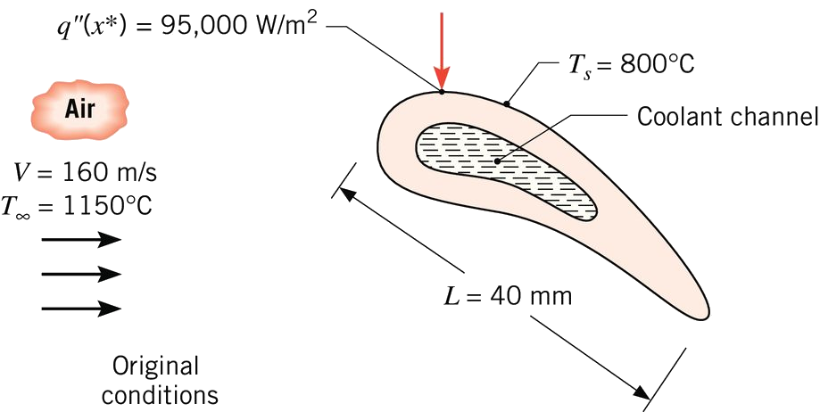

## Required:

Determine the heat flux to the blade at $x^*$ if its temperature is reduced to $T_{s,1} = 700\ \mathrm{°C}$ by increasing the coolant flow. Determine the heat flux at the same dimensionless location $x^*$ for a similar turbine blade having a chord length of $L = 80\ \mathrm{mm}$, when the blade operates in an airflow at $T_\infty = 1150\ \mathrm{°C}$ and $V = 80\ \frac{\mathrm{m}}{\mathrm{s}}$, with $T_s = 800\ \mathrm{°C}$.

## Solution:

Start first by defining all of the given values.

$$q^{\prime\prime} = 95\ \frac{\mathrm{kW}}{\mathrm{m}^{2}}$$
$$V = 160\ \frac{\mathrm{m}}{\mathrm{s}}$$
$$T_\infty = 1150\ \mathrm{°C} = 1423.15\ \mathrm{K}$$
$$T_s = 800\ \mathrm{°C} = 1073.15\ \mathrm{K}$$
$$L = 40\ \mathrm{mm}$$
$$T_{s,1} = 700\ \mathrm{°C} = 973.15\ \mathrm{K}$$
$$L_2 = 80\ \mathrm{mm}$$
$$V_2 = 80\ \frac{\mathrm{m}}{\mathrm{s}}$$

Newton’s law of cooling for the blade is

$$q^{''}=h \left( T_\infty - T_s\right)$$

Solving this for the convective coefficient shows

$$h = \frac{q^{\prime\prime}}{T_\infty - T_s} = 271.4\ \frac{\mathrm{W}}{\left(\mathrm{K} \cdot \mathrm{m}^{2}\right)}$$

Now for a different surface temperature, the convective coefficient may be different. In order to determine if the convective coefficient changes or stays the same, the Nusselt number may be compared for the two cases. The Nusselt number is defined as

$$Nu=\frac{h L}{k}$$

The Nusselt number is also known to be a function of $x^*$, $Re_L$, and $Pr$ or

$$Nu=f\left(x^*, Re_L, Pr \right)$$

Recalling the definitions of Reynolds and Prandtl number as

$$Re_L=\frac{V L}{\nu}$$

$$Pr=\frac{\nu}{\alpha}$$

Assuming constant material properties (i.e. $\nu$, $\alpha$, and $k$ are constant), the Nusselt number remains constant for the same characteristic location $x^*$. Thus,

$$Nu=Nu_1$$

or

$$\frac{h L}{k} = \frac{h_1 L_1}{k_1}$$

Solving for the convective coefficient $h_1$ shows

$$h_1 = h\frac{L}{L_1}\frac{k_1}{k} = h = 271.4\ \frac{\mathrm{W}}{\left(\mathrm{K} \cdot \mathrm{m}^{2}\right)}$$

The heat flux for the surface temperature $T_{s,1}$ case is then

Answer, part 1: $q^{\prime \prime}_{1} = h_1 ( T_\infty - T_{s1}) = 122.1\ \frac{\mathrm{kW}}{\mathrm{m}^{2}}$

For the second part, the length and velocity are changed by the following relationship.

$$L_2=2L$$

$$V_2=\frac{V}{2}$$

Since the length and velocity are changed, the Reynolds number will possibly be affected. Looking at the Reynolds number for the second part shows

$$Re_{L,2}=\frac{V_2 L_2}{\nu}=\frac{\frac{V}{2} \left(2L\right)}{\nu}=\frac{V L}{\nu}=Re_L$$

This shows that the Reynolds number does not change. Since the Reynolds number does not change, the Nusselt numbers remain the same for the same characteristic location $x^*$ and constant $Pr$ value. Thus,

$$Nu_2 = Nu$$

or

$$\frac{h_2 L_2}{k_2} = \frac{h L}{k}$$

Solving for the convective coefficient for the second part (for constant $k$ values) shows

$$h_2 = h \frac{L}{L_2} \frac{k_2}{k} = h \frac{L}{L_2} = 135.7\ \frac{\mathrm{W}}{\left(\mathrm{K} \cdot \mathrm{m}^{2}\right)}$$

Using Newton’s law of cooling, the heat flux for the second part is

Answer, part 2: $q^{\prime \prime}_{2} = h_2 ( T_\infty - T_s) = 47.5\ \frac{\mathrm{kW}}{\mathrm{m}^{2}}$

**Note**

It should be noted that constant material properties were assumed in the solution shown above. This may not necessarily be valid. While a constant material property assumption need not be made, another assumption must be made. There must be an underlining assumption that there is similarities between the different cases (i.e. the Nusselt numbers remain the same). This is not always the case (actually, most of the time it is not true). However, the following analysis makes such an assumption. This analysis begins by calculating the average temperature for the initial case. This is shown below.

$$\bar{T} = \frac{T_s + T_\infty}{2} = 1248.2\ \mathrm{K} = 975.0\ \mathrm{°C}$$

Going to Table A.4 for Air at $\bar{T}_1$ shows that interpolation is needed for the thermal conductivity. This is shown below.

$$T_A = 1200\ \mathrm{K} = 926.85\ \mathrm{°C}$$
$$T_B = 1300\ \mathrm{K} = 1026.85\ \mathrm{°C}$$
$$k_A = 0.0763\ \frac{\mathrm{W}}{\left(\mathrm{K} \cdot \mathrm{m}\right)}$$
$$k_B = 0.082\ \frac{\mathrm{W}}{\left(\mathrm{K} \cdot \mathrm{m}\right)}$$
$$k = \frac{\bar{T} - T_A}{T_B - T_A}(k_B - k_A) + k_A = 79.04\ \frac{\mathrm{mW}}{\left(\mathrm{K} \cdot \mathrm{m}\right)}$$

This process may be repeated for the case of the surface temperature $T_{s,1}$. The average temperature for this case is

$$\bar{T}_{1} = \frac{T_{s1} + T_\infty}{2} = 1198.2\ \mathrm{K} = 925.0\ \mathrm{°C}$$

Going to Table A.4 for Air at $\bar{T}_1$ shows that interpolation is needed for the thermal conductivity. This is shown below.

$$T_A = 1200\ \mathrm{K} = 926.85\ \mathrm{°C}$$
$$T_B = 1300\ \mathrm{K} = 1026.85\ \mathrm{°C}$$
$$k_A = 0.0763\ \frac{\mathrm{W}}{\left(\mathrm{K} \cdot \mathrm{m}\right)}$$
$$k_B = 0.082\ \frac{\mathrm{W}}{\left(\mathrm{K} \cdot \mathrm{m}\right)}$$
$$k_1 = \frac{\bar{T_1} - T_A}{T_B - T_A}(k_B - k_A) + k_A = 76.19\ \frac{\mathrm{mW}}{\left(\mathrm{K} \cdot \mathrm{m}\right)}$$

Using the assumption that the Nusselt numbers remain the same, the following is true.

$$Nu=Nu_1$$

or

$$\frac{h L}{k} = \frac{h_1 L_1}{k_1}$$

Knowing $L=L_1$, the convective coefficient $h_1$ may be found. This is shown below.

$$h_1 = h \frac{L}{L_1} \frac{k_1}{k} = h \frac{k_1}{k} = 261.6\ \frac{\mathrm{W}}{\left(\mathrm{K} \cdot \mathrm{m}^{2}\right)}$$

The heat flux is then given by

Alternative Answer, part 1: $q^{\prime \prime}_{1} = h_1 ( T_\infty - T_{s1}) = 117.7\ \frac{\mathrm{kW}}{\mathrm{m}^{2}}$

Reviewing the analysis for the second part shows that the thermal conductivity is the same for both cases (i.e., $k=k_2$). Thus, the answer to the second part will be no different.